# COMM 3710: Introduction

[figure not shown]

> Welcome to a new semester and to COMM 3710! COMM 3710 is an asynchronous online course. For more information on the course, please see the [course syllabus](https://rpubs.com/yesun/COMM3710syllabus).

> It is your responsibility to read the syllabus in its entirety and adhere to the course policies and information documented therein. Please revisit the syllabus as many times as necessary during the semester.

# A Brief Introduction

Welcome to COMM 3710! Because of the coronavirus pandemic, COMM 3710 has moved online and will primarily be asynchronous. For more information on the course, please see the [course syllabus](https://rpubs.com/yesun/COMM3710syllabus).

I’m Prof. Sun and I’m an Associate Professor in the Department of Communication. I do empirical research in the areas of health communication, media effects, and meta-science. You can know more about my work [here](https://ye0sun.wixsite.com/academic) if you are interested.

Back to top

# Some Highlights from the Syllabus

## Course Textbook

Your textbook is available on Canvas through Inclusive Access. It is a great resource and I highly encourage you to use it as we progress through the semester.

Additional readings will be available as PDFs on Canvas.

Back to top

## Technology

1. Ensure that you are familiar with Canvas. Set up your notifications according to your preferences. If you need help with Canvas, review this [page](https://support.tlt.utah.edu/hc/en-us/articles/205654094).
2. Check your University email account (unid@utah.edu) regularly. Ideally, you should check this email account every day. If you need to contact me, please email me at my Umail (ye.sun@utah.edu).
3. You will need Microsoft software (Word, Excel, PowerPoint) and Adobe Acrobat.
4. You will also need access to [R](https://www.r-project.org/). More information about R will be provided as the semester progresses.
5. You will need a webcam and a microphone to participate in drop-in office hours. We will use [Zoom](https://zoom.us/) for virtual office hours.
6. The U’s [Teaching & Learning Technologies](https://tlt.utah.edu/) recommends that you have the **latest versions of at least two** browsers installed. The preferred web browser is [Google Chrome](https://www.google.com/chrome/browser/desktop/).

Back to top

# Some Helpful Resources

## Canvas Help

If you need help in Canvas, click the `Help` button in the right sidebar or contact:

- **Phone:** +1 844-527-0328
- [**Chat** with Canvas Support](https://cases.canvaslms.com/liveagentchat?chattype=student)

## Campus Help Desk

For help with UMail, uNID, VPN, Box, Office 365, and CIS log-in, contact the Campus Help Desk:

- Phone: 801-581-4000 (option 1)
- Email: helpdesk@utah.edu
- Website: https://it.utah.edu/help/

Help is available Monday through Saturday. Please visit the [Campus Help Desk website](https://it.utah.edu/help/) for more information.

Back to top

# Note-taking for Success in College

**I recommend taking notes while you review the content online. This will help you learn and recall material.**

One note-taking system that you might consider trying is the [Cornell system](http://lsc.cornell.edu/study-skills/cornell-note-taking-system/). This system is detailed in the book below:

> Pauk, W., & Owens, R. J. Q. (2013). *How to Study in College* (11 edition). Cengage Learning.

Back to top

# An Introduction to Social Science

Let’s begin by discussing two broad types of sciences: **physical** and **social sciences**.

The **physical sciences** involve studying the objective aspects of nature. Typically, we think of physics, biology, and chemistry when we think of the physical sciences.

The **social sciences**, on the other hand, is the study of how humans live and interact. This includes disciplines such as psychology, communication, and history. The flavor of communication research that we will learn about in this course is a type of social science.

This week, we will begin by examining the history of social sciences and how the field of communication developed.

Back to top

# A (Brief) History of the Social Sciences

Ancient Greek scholars did not make a distinction between the *social* and *physical* sciences. In fact, many studied both and considered both physical and social processes as things to be studied scientifically. Here are a few examples:

1. **Hippocrates of Cos**

Hippocrates was the first scientist (or philosopher) to classify his patients according to personality. He was, of course, also a physician–many of us will be familiar with the [Hippocratic oath in medicine](https://www.nlm.nih.gov/hmd/greek/greek_oath.html). Interestingly, the phrase that commonly attributed to this oath, “First, do no harm,” is **not** explicitly contained within this text. Instead, there are [modern versions](https://www.pbs.org/wgbh/nova/doctors/oath_modern.html) that some medical schools adopt.

2. **Plato**

Plato used geometric proofs, a physical science concept, to study the intrinsic state of knowledge, which is a social scientific concept.

3. **Aristotle**

Aristotle studied poetry and rhetoric with the same scientific rigor and processes with which he studied planetary motion.

This lack of division between physical and social sciences stayed intact until the publication of **Sir Isaac Newton**’s *Philosophiae Naturalis Principia Mathematica* (Mathematical Principles of Natural Philosophy) in 1687. This is considered one of the most important works in the history of science.

- In these volumes, Newton argues that the underlying rule of all physical nature is mathematics.

[figure not shown]

As a result, physical scientists gravitated to and successfully applied Newton’s writings. Social scientists, on the other hand, were slower to make their studies more quantitative.

**Charles Darwin**’s theory was another point at which we see a divide between the “hard” and social sciences; social scientists were slower than biologists to see how Darwin’s theory applied to social science.

[figure not shown]

In the late 1800’s to the early 1900’s, quantitative measurements in the physical sciences became the norm.

Then, at the turn of the 20th century, we begin to see a divide among scholars who study humans and the **social scientific** vs. the **humanistic perspectives** emerge.

## Social Sciences Research Post-WWI

By the 1920s, marketing agencies were surveying consumer behavior, and politicians and media outlets realized that the new techniques being created by social scientists to research humans could examine political preferences. This resulted in new ways of measuring attitudes, many of which we still use today.

For example, the *Likert* and *semantic differential* scales were developed during this time:

Likert, R. (1932). A technique for the measurement of attitudes (Ph.D.). Columbia University, New York, NY. Retrieved from http://psycnet.apa.org/record/1933-01885-001

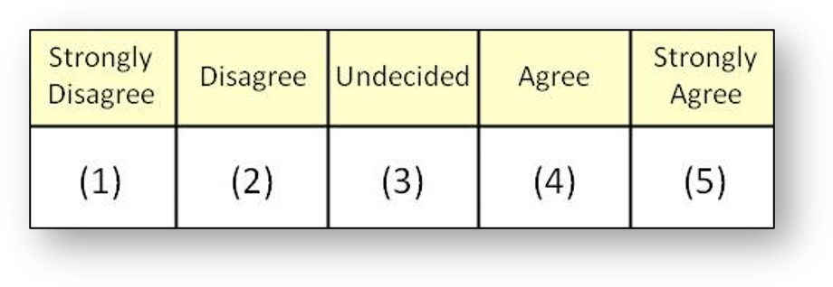

Osgood, C. E. (1952). The nature and measurement of meaning. *Psychological Bulletin*, *49(3)*, 197–237. https://doi.org/10.1037/h0055737

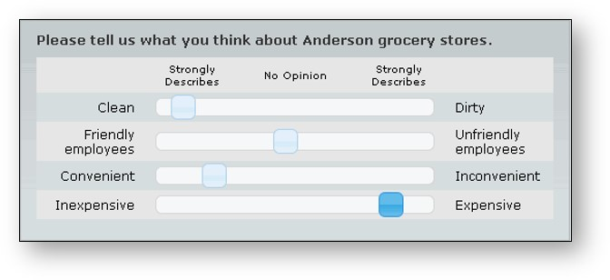

Back to top

## Social Science Research During and Post-WWII

During WWII, the US government became more involved in social science research in order to understand propaganda, public opinion, and persuasion. In order to main high morale during wartime, the US government realized that media was critical and created the [US Office of War Information](https://en.wikipedia.org/wiki/United_States_Office_of_War_Information).

In 1941, [Paul Lazarsfeld](http://www.nasonline.org/publications/biographical-memoirs/memoir-pdfs/lazarsfeld-paul-f.pdf) and his colleagues at the [Bureau of Applied Social Research at Columbia University](http://www.iserp.columbia.edu/about/iserp-history) published the first review of the discipline of communication. In this review, they identified 4 categories of communication:

1. Who…
2. said what…
3. to whom…
4. and with what effect?

Another important milestone in the history of communication research is the work of [Carl Hovland](http://www.apadivisions.org/division-1/publications/newsletters/general/2017/06/hovland-profile.aspx)’s group at Yale University. This group examined a wide range of variables shown to influence persuasion including sources credibility, personality traits, and fear appeals.

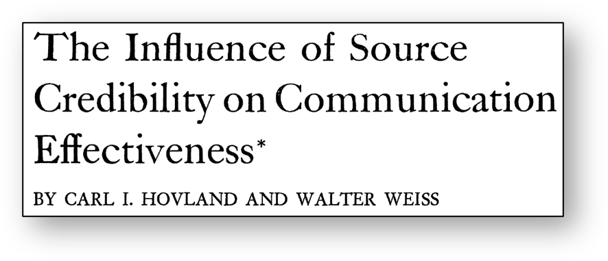

The legacy of research conducted by Hovland’s group led to future researchers examining other communication contexts. To get a better idea of how research from this historical legacy has influenced the discipline of communication, see Figure 1.1 in the textbook.

Back to top

# Epistemologies in Communication Research

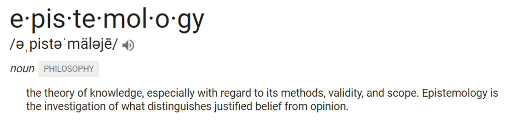

In communication research, there are 3 epistemological traditions:

1. social scientific (positivism)
2. qualitative (interpretive)
3. rhetorical (critical)

## Social Scientific Perspective / Positivism

Social scientific researchers rely primarily on quantitative methodologies and believe human communication can be examined through both simple and complex statistical models.

An example of a research question that might be asked in this tradition is “What is the effect of extreme weather on tweets about climate change?”

- Yeo, S. K., Handlos, Z. J., Karambelas, A., Su, L. Y.-F., Rose, K. M., Brossard, D., & Griffin, K. S. (2017). The influence of temperature on topics of Twitter discourse about #climatechange and #globalwarming. *Journal of Science Communication*, *16(5)*, 1–25.

**This is the epistemological tradition on which this course is based.**

## Qualitative / Interpretive

Qualitative researchers believe that to understand human communication, one must explore and appreciate how individuals at the center of specific interactions or communicative acts understand their own communication.

An example of a research question that might be asked in this tradition is “What does it mean to be a member of the LDS church?”

## Rhetorical / Critical

Rhetorical/Critical scholars believe the central role of research is to examine the interplay between ideology and science.

An example of a research question that might be asked in this tradition is “How are crisis messages steeped in power and privilege?”

# Ordinary vs. Scientific Ways of Knowing

It is also integral that we articulate and know the distinction between ordinary (or common) and scientific ways of knowing. Importantly, the difference between these ways of knowing lies in the **process**.

## Ordinary Ways of Knowing

1. **Tradition**: This is often determined by culture. It is undeniable that traditions dictate how we interact and communicate with each other.
2. **Authority**: We also come to know things by relying on experts. For example, we rely on our doctors for health information and on priests for religious teachings.

Back to top

## Scientific Ways of Knowing

As mentioned, the difference between ordinary and scientific ways of knowing has to do with the **process** of generating scientific knowledge. This process relies on 6 steps:

1. **Conceptualization**: When we rely on scientific ways of knowing, it is important to delineate what is being studied and what is not.
2. **Reading the literature**: Reviewing what has already been done is important. We need to ensure that our scientific knowledge is supported by data-driven evidence, not just opinion.
3. **Careful measurements**: The ability to quantify something allows us to have an objective way of arriving at knowledge.
4. **Collecting samples**: Samples allow us to make predictions about larger populations. For example, in order to make predictions about U.S. adults, researchers often take samples of 1,000 respondents. If the sample is representative of the population, then we can make accurate and valid inferences (more about this in Week 10 when we discuss sampling).
5. **Analyzing data and presenting results**: Because scientific ways of knowing rely on objective data, scientists can spend entire careers learning how to analyze data.
6. **Ethics and politics**: Importantly, researchers and scientists must collect, analyze, and report data in ethical ways, which include minimizing potential biases.

Back to top

# The Wheel of Science

A figure representing the “wheel” of science can be found in your textbook (Figure 2.1). Your textbook refers to this as the scientific method. Below is a short video explanation of the “wheel” of science.

[video not shown]

Next, let’s practice identifying some inductive and deductive forms of reasoning. **Watch the clip below from Monty Python and the Holy Grail and try to identify the type of reasoning (inductive or deductive) used in various parts** (*Hint*: Both inductive and deductive logic is used at different times in the clip).

[video not shown]

Check your answers using the video below:

[video not shown]

Back to top

# Defining Research

Watch the video below defining “research.”

[video not shown]

## Probabilistic vs. Deterministic Predictions

[figure not shown]

**Deterministic predictions**

- All data are known (i.e., one can *determine* the outcome).
- Example: Predicting the amount of money you will have in your bank account next year.

**Probabilistic predictions**

- There is an element of chance involved. When we do not have all the data, our predictions will necessarily be probabilistic.
- Example: Predicting human communication behavior and attitudes.

Back to top